# 1

This data set contains information student learning collected by a survey in 2014-2015. Information included are respondent gender, age, points along with measures on attitude, deep learning and strategy, which are a sample data from a larger data set.

Original data set includes information on 182 students on a course on social statistics (Course: Johdatus yhteiskuntatilastotieteeseen, syksy 2014 ("Introduction to Social Statistics, fall 2014 - in Finnish) by a survey with questions on teaching and learning.

More information on the original data set, variables and origin of the data from Kimmo Vehkalahti, and: http://www.helsinki.fi/~kvehkala/JYTmooc/JYTOPKYS2-meta.txt

# 2 Graphical Overview and Summaries of Variables

```r
date()
```

```
## [1] "Thu Nov 05 22:38:20 2020"
```

```r
#install.packages("ggplot2")
#install.packages("GGally")
library(ggplot2)
library(GGally)
df <- read.table( "Z:/FDPE/Courses/Datamooc/IODS-project/data/learning2014.txt", sep = "\t", header = TRUE)

str(df)
```

```
## 'data.frame':    165 obs. of  7 variables:
##  $ gender  : chr  "M" "F" "M" "M" ...
##  $ age     : int  55 49 53 49 38 50 37 37 42 37 ...
##  $ attitude: int  31 25 35 37 38 35 29 38 21 39 ...
##  $ deep    : num  2.92 3.5 3.5 3.67 4.75 ...
##  $ stra    : num  2.75 3.62 3.12 3.62 3.62 ...
##  $ surf    : num  3.17 2.25 2.25 2.83 2.42 ...
##  $ points  : int  12 24 10 22 21 21 31 24 26 31 ...
```

```r
head(df)
```

```
##   gender age attitude     deep  stra     surf points
## 1      M  55       31 2.916667 2.750 3.166667     12
## 2      F  49       25 3.500000 3.625 2.250000     24
## 3      M  53       35 3.500000 3.125 2.250000     10
## 4      M  49       37 3.666667 3.625 2.833333     22
## 5      F  38       38 4.750000 3.625 2.416667     21
## 6      M  50       35 3.833333 2.250 1.916667     21
```

```r
summary(df)
```

```
##     gender               age           attitude          deep
##  Length:165         Min.   :17.00   Min.   :14.00   Min.   :1.583
##  Class :character   1st Qu.:21.00   1st Qu.:26.00   1st Qu.:3.333
##  Mode  :character   Median :22.00   Median :32.00   Median :3.667
##                     Mean   :25.35   Mean   :31.39   Mean   :3.680
##                     3rd Qu.:27.00   3rd Qu.:37.00   3rd Qu.:4.083
##                     Max.   :55.00   Max.   :50.00   Max.   :4.917
##       stra            surf           points
##  Min.   :1.250   Min.   :1.583   Min.   : 7.0
##  1st Qu.:2.625   1st Qu.:2.417   1st Qu.:19.0
##  Median :3.125   Median :2.833   Median :23.0
##  Mean   :3.120   Mean   :2.788   Mean   :22.7
##  3rd Qu.:3.625   3rd Qu.:3.167   3rd Qu.:28.0
##  Max.   :5.000   Max.   :4.333   Max.   :33.0
```

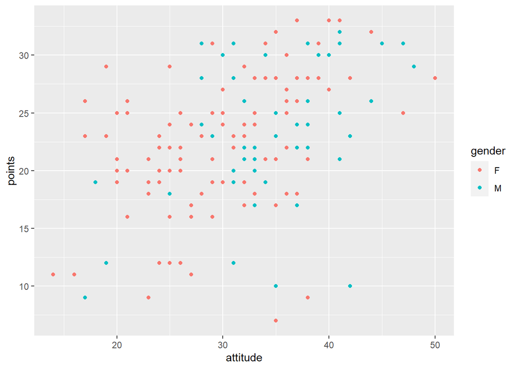

```r
# initialize plot with data and aesthetic mapping
p1 <- ggplot(df, aes(x = attitude, y = points, col = gender))

# define the visualization type (points)
p2 <- p1 + geom_point()

# draw the plot
p2
```

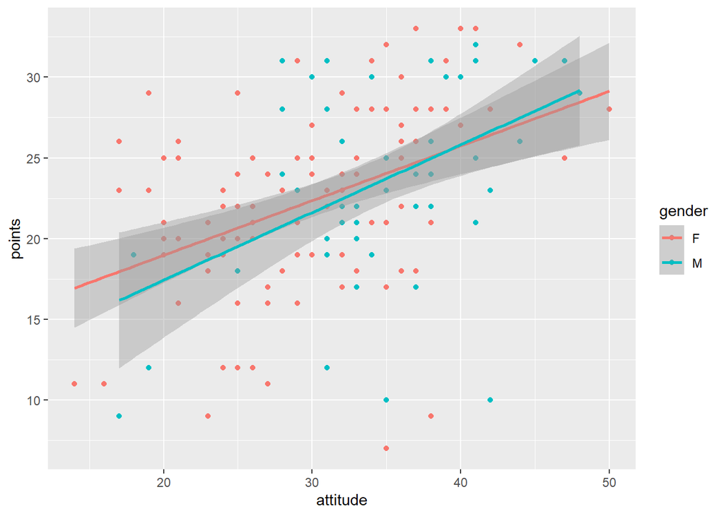

```r
# add a regression line
p3 <- p2 + geom_smooth(method = "lm")
p3
```

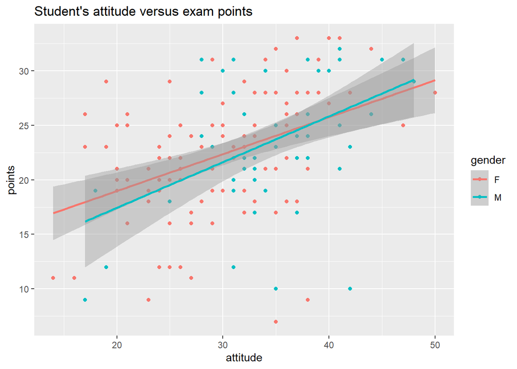

```r
# add a main title and draw the plot
p41 <- p3 + ggtitle("Student's attitude versus exam points")
p41
```

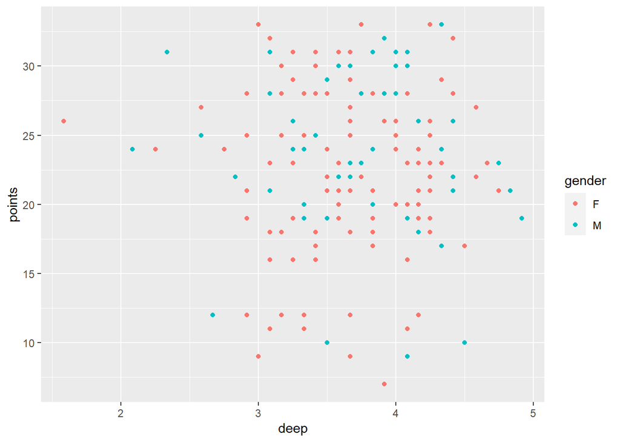

```r
# Deep Approach
p1 <- ggplot(df, aes(x = deep, y = points, col = gender))
p2 <- p1 + geom_point()
p2
```

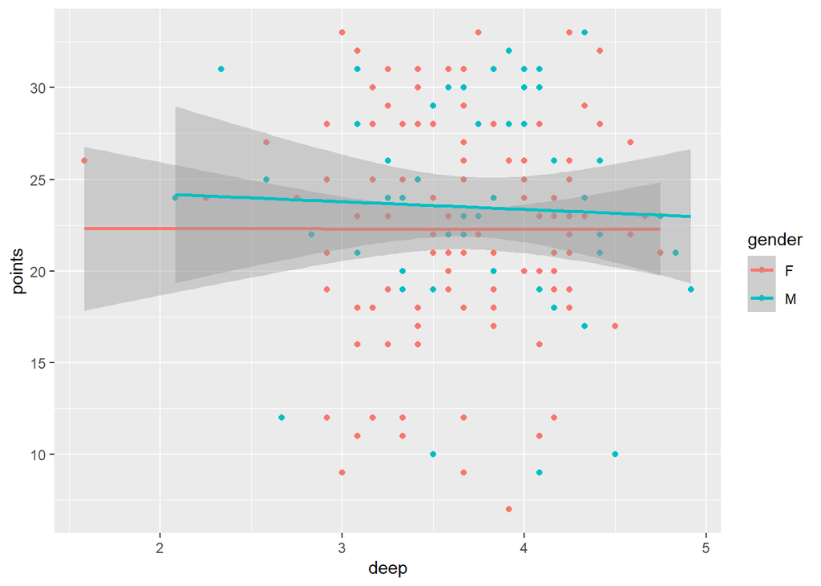

```r
p3 <- p2 + geom_smooth(method = "lm")
p3
```

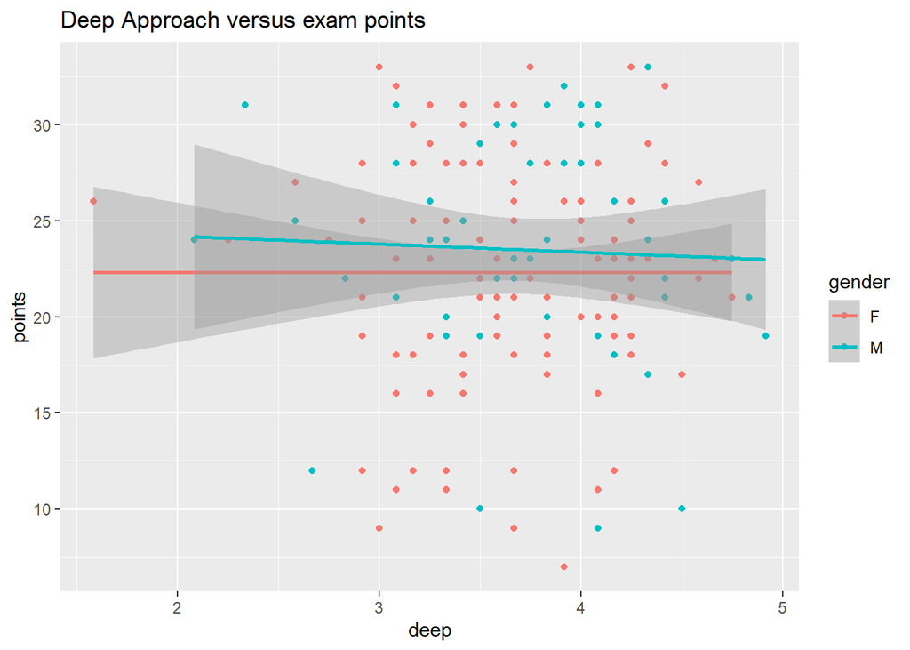

```r
p42 <- p3 + ggtitle("Deep Approach versus exam points")
p42
```

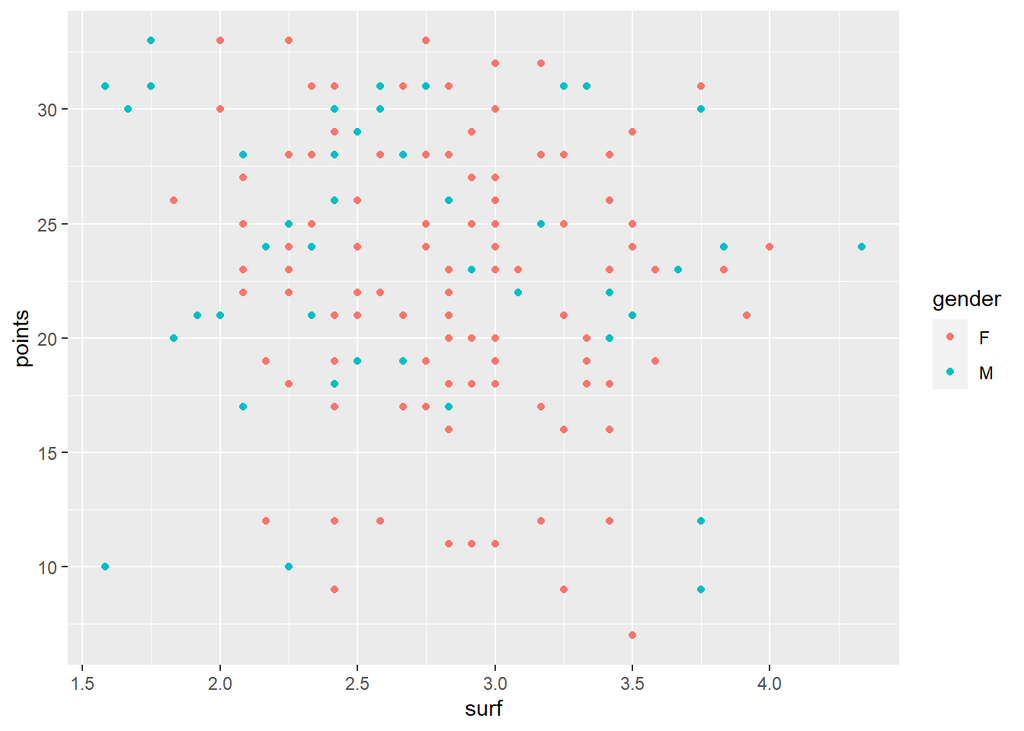

```r
# Surface Approach
p1 <- ggplot(df, aes(x = surf, y = points, col = gender))
p2 <- p1 + geom_point()
p2
```

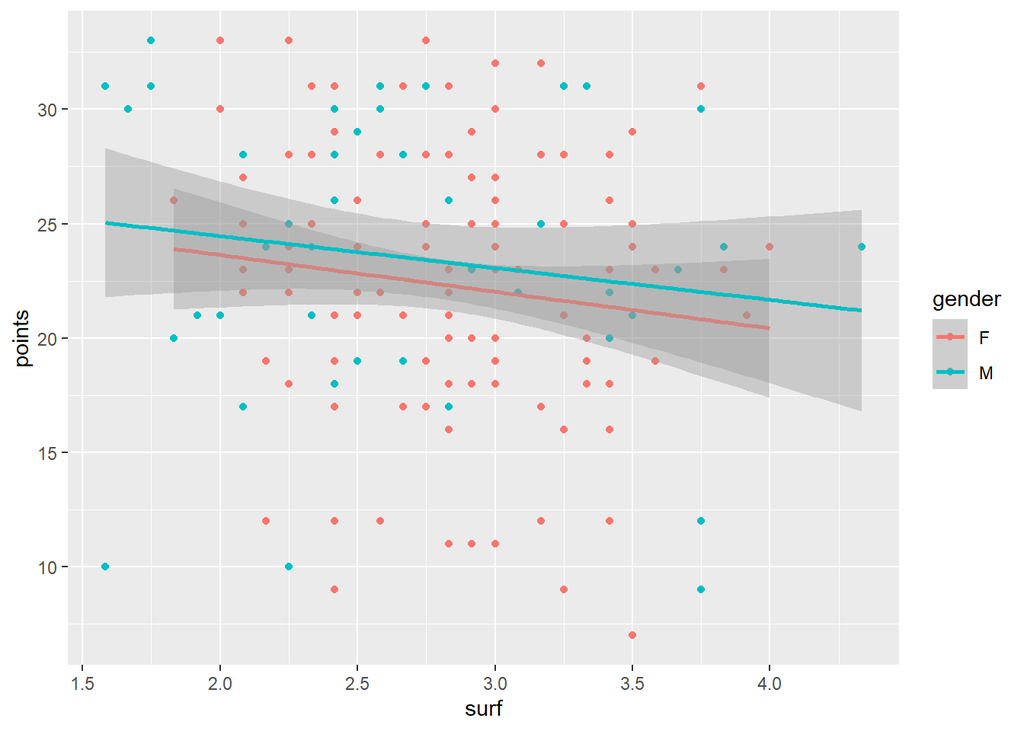

```r
p3 <- p2 + geom_smooth(method = "lm")
p3
```

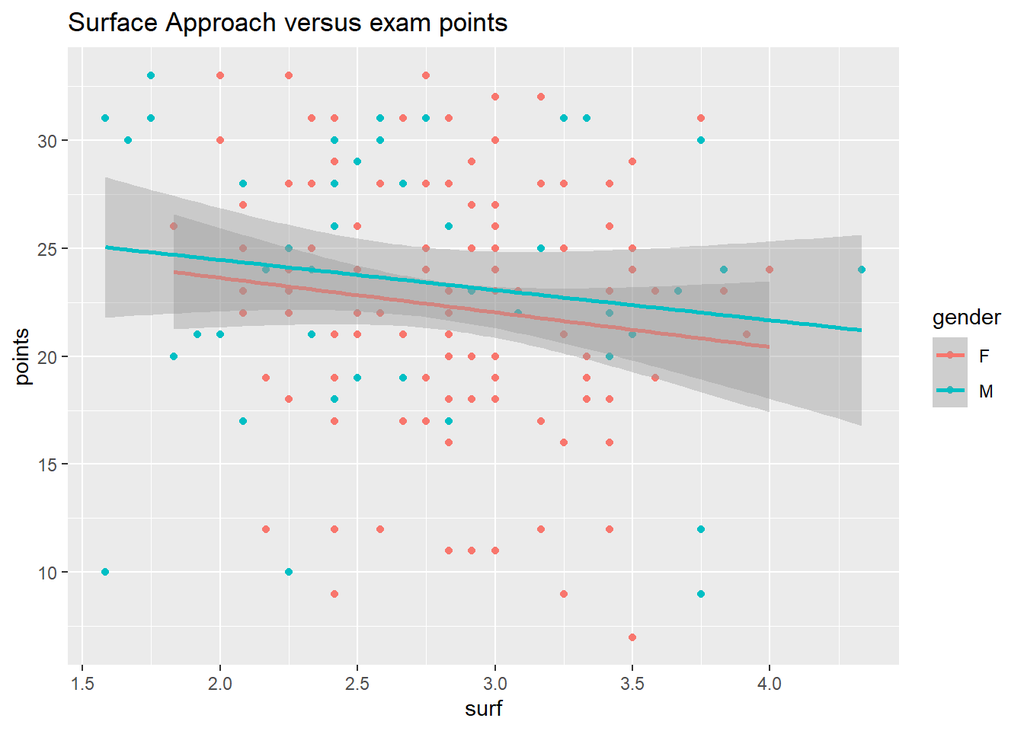

```r
p43 <- p3 + ggtitle("Surface Approach versus exam points")
p43
```

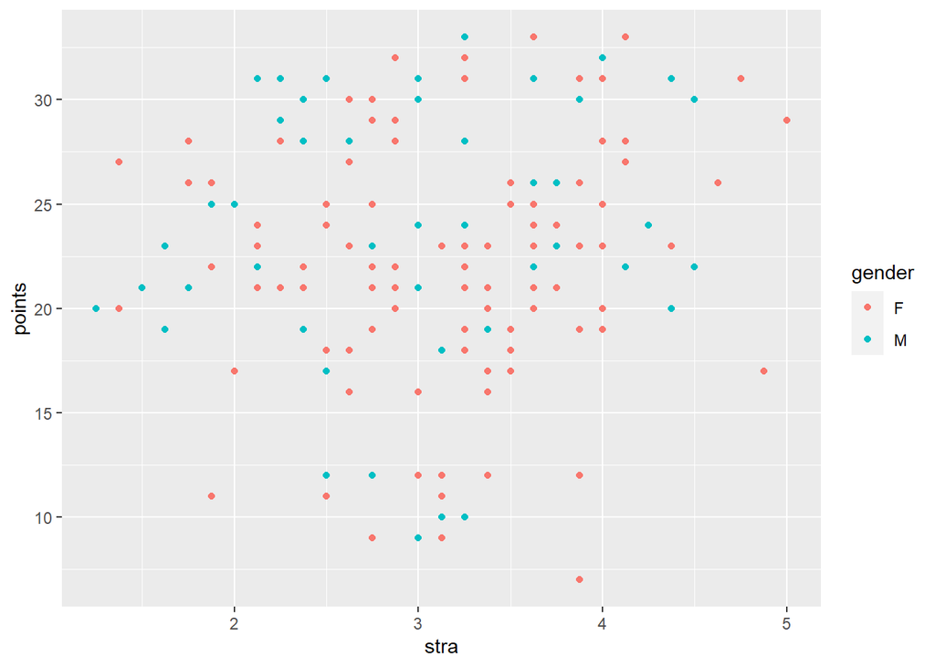

```r
# Strategic Approach
p1 <- ggplot(df, aes(x = stra, y = points, col = gender))
p2 <- p1 + geom_point()
p2
```

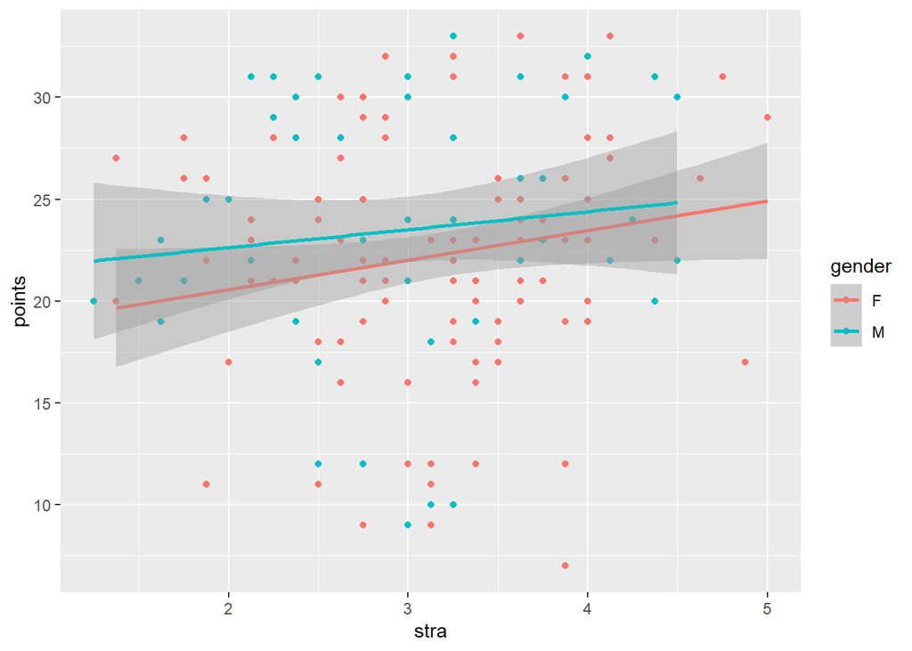

```r
p3 <- p2 + geom_smooth(method = "lm")
p3
```

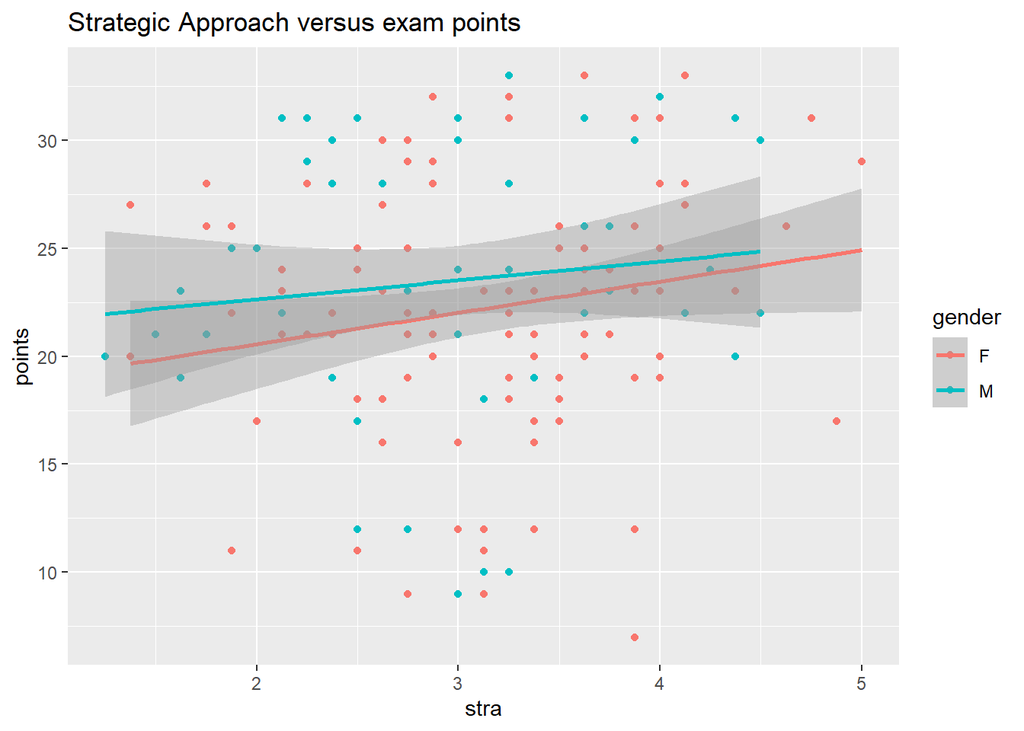

```r
p44 <- p3 + ggtitle("Strategic Approach versus exam points")
p44
```

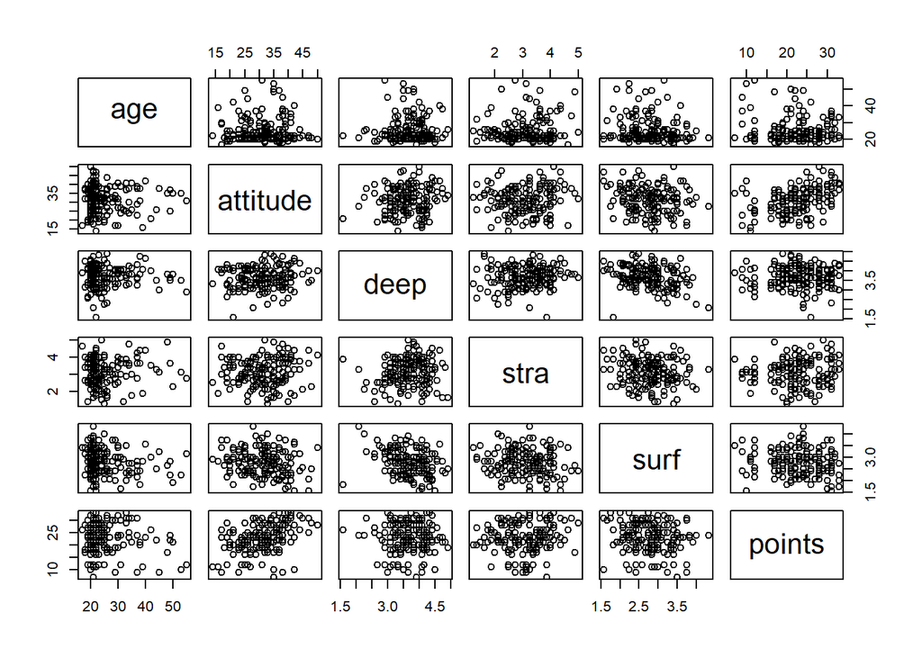

```r
##
# draw a scatter plot matrix of the variables in learning2014.
# [-1] excludes the first column (gender)
pairs(df[-1])
```

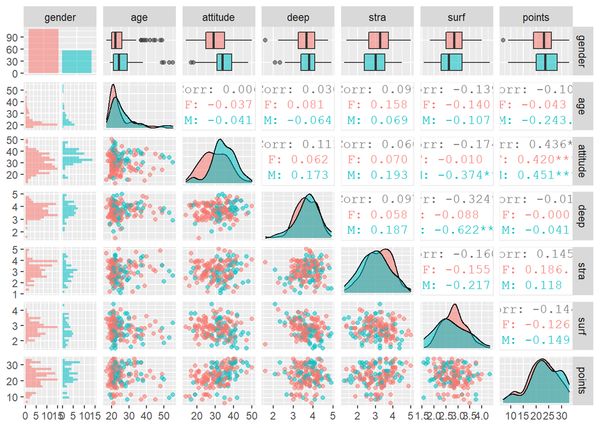

```r
# create a more advanced plot matrix with ggpairs()
p <- ggpairs(df, mapping = aes(col = gender, alpha = 0.3), lower = list(combo = wrap("facethist", bins = 20)))

# draw the plot
p
```

```r
fit1 <- lm(points ~ attitude + gender + age , data = df)

summary(fit1)
```

```
##
## Call:
## lm(formula = points ~ attitude + gender + age, data = df)
##
## Residuals:
##      Min       1Q   Median       3Q      Max
## -17.4523  -3.3523   0.1727   4.0721  10.4474
##
## Coefficients:
##             Estimate Std. Error t value Pr(>|t|)
## (Intercept) 13.65355    2.35119   5.807 3.30e-08 ***
## attitude     0.35835    0.05970   6.003 1.24e-08 ***
## genderM     -0.28351    0.92770  -0.306    0.760
## age         -0.08303    0.05617  -1.478    0.141
## ---
## Signif. codes:  0 '***' 0.001 '**' 0.01 '*' 0.05 '.' 0.1 ' ' 1
##
## Residual standard error: 5.328 on 161 degrees of freedom
## Multiple R-squared:  0.202,  Adjusted R-squared:  0.1872
## F-statistic: 13.59 on 3 and 161 DF,  p-value: 6.03e-08
```

```r
# Removing gender and age:

fit2 <- lm(points ~ attitude, data = df)

summary(fit2)
```

```
##
## Call:
## lm(formula = points ~ attitude, data = df)
##
## Residuals:
##      Min       1Q   Median       3Q      Max
## -16.9736  -3.2119   0.4358   4.1975  10.6639
##
## Coefficients:
##             Estimate Std. Error t value Pr(>|t|)
## (Intercept) 11.64162    1.83744   6.336 2.21e-09 ***
## attitude     0.35234    0.05701   6.180 4.95e-09 ***
## ---
## Signif. codes:  0 '***' 0.001 '**' 0.01 '*' 0.05 '.' 0.1 ' ' 1
##
## Residual standard error: 5.336 on 163 degrees of freedom
## Multiple R-squared:  0.1898, Adjusted R-squared:  0.1849
## F-statistic: 38.19 on 1 and 163 DF,  p-value: 4.947e-09
```

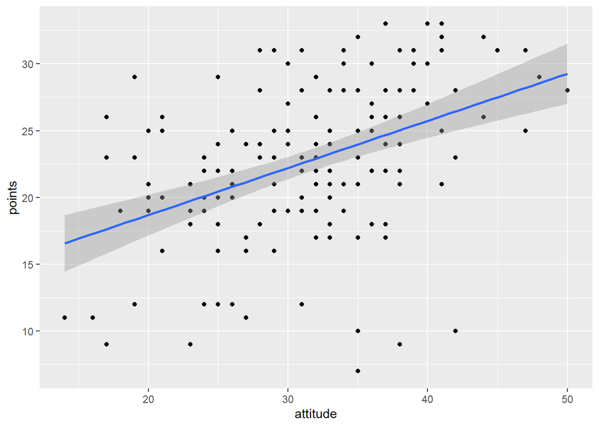

```r
q <- qplot(attitude, points, data = df) + geom_smooth(method = "lm")
q
```

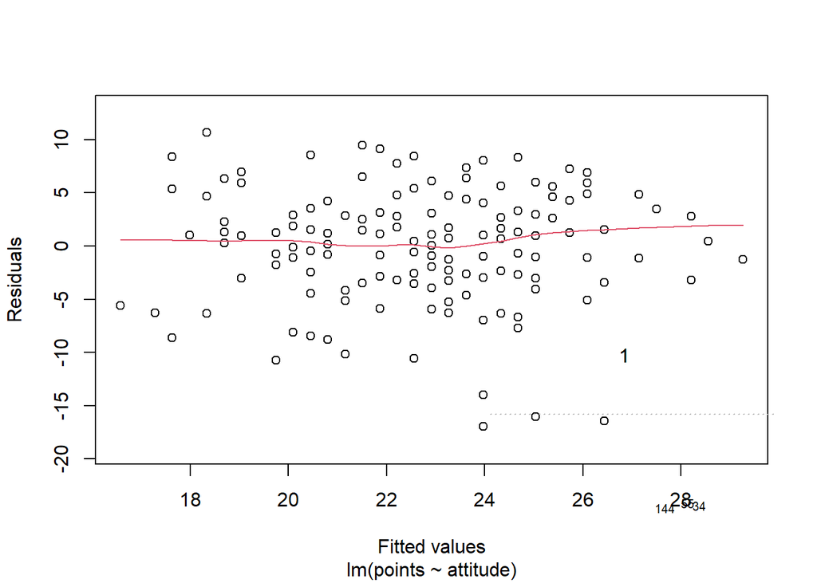

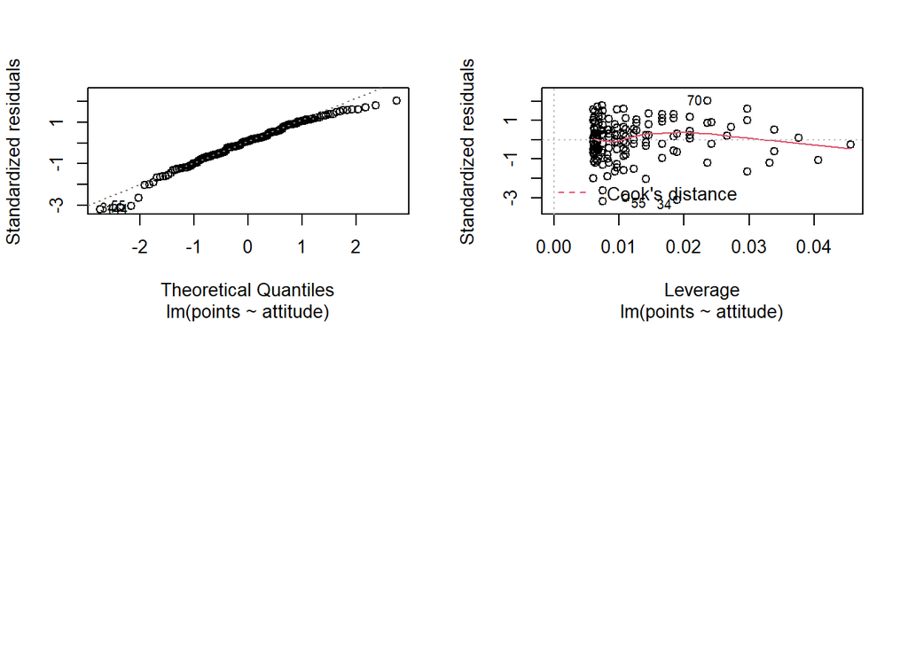

```r
# Diagnostics
#plot(fit2, which = c(1,2,5))
plot(fit2, which = c(1,2,5), par(mfrow = c(2,2)))
```

By looking at the simple figures we can see that student attitude as well as strategic approach seam to be positively correlated whereas surface approach is negatively correlated with performance (points). All of the relations are quite moderate with attitude showing strongest connection to performace while the correlations between deep approach and points being close to zero. The relations are quite similar by gender, although the correlation between points and attitude is slightly stronger for men.

By using GGally we can get a more thorough understanding of the descriptives between the variables. Now we see for example that there are near to twice the amount of women compared to men in the sample and that while the distributions of overall points are similar to men and women, they rely on somewhat different learning strategies.

# 3 Fitting a Regression Model

Three explanatory (x) variables: attitude, gender, age

Fitting the regression model such that the variation in points (target variable) is explained by the variation in three explanatory variables attitude, gender and age (fit1). Treating age and gender as control variables in this model and the coefficient of attitude as the main parameter of interest, we can interpret the parameter beta_attitude: Keeping age and gender constant, one level increase in attitude (likert scale) is associated with 0.358 increase in points. With standard error 0.05970, this estimate is statistically significant at 1% level, which indicates there is less than 1% probability that the null hypothesis is true and we reject the null of no difference in means.

The hypothesis test here tests the null hypothesis that the parameter of each explanatory variable is zero. With multiple parameters this is done with the F-test with F-statistic printed with the regression output. The F-statistic: 38.19 on 1 and 163 DF associated with the second model rejects the null of no association.

# 4 Interpreting the results

After removing the not statistically significant variables age and gender (fit2) - and the explained part of the variation by them - as instructed, the coefficient drops slightly in magnitude to 0.35234 (0.05701) indicating again that one unit increase in attitude level is associated with 0.35 point increase in total points on average. The coefficient is highly statistically significant (1% level).

The multiple R-squared is a measure of amount of variation of the outcome variable that is explained by the explanatory variables in total. The multiple R-squared drops slightly from 0.202 associated with the first model with all three explanatory variables to 0.1898 in the simpler model. The difference is quite small indicating the small amount of variation that gender and age explain on the variation in performance (points).

#5 Diagnostics: Residuals vs Fitted values, Normal QQ-plot and Residuals vs Leverage

The assumptions of the model and looking at the diagnostics plots:

Error terms are not correlated.

Constant variance assumption ( & Residuals vs Fitted): The size of the errors should not depend on the explanatory variables. Looking at the first figure, there doesnt seam to be any relation as implied by the almost horizontal red line.

Errors are normally distributed ( & QQ-plot) : Error terms are assumed to be normally distributed with mean mu and variance sigma^2. Looking at the QQ-plot, as the residuals seem fairly well fitted on the diagonal, there are not much concern on violation of this assumption. There are some deviations on very small and very large values.

Looking at the last plot ( & Ressiduals vs Leverage), we can check for big outliers in our sample. Cook’s distance is a measure of the effect of removing any single point. If there are any highly influential point with high leverage, they show up outside with given intervals – although here, as we do not have big outliers, not even the intervals are showing.The same plot can be used to check for heteroskedasticity (changing spread indicates heteroskedasticity) and non-linearity.